# A Crash Course in R

#### Conditional variables

We can create a variable whose value is conditional on another variable using `if_else`. This function takes a logical expression as its first argument, and then its second and third arguments provide the result if the expression is true or false respectively. Let’s make a variable called `lots_of_controls` which is `"Y"` if `ncontrols` is greater than 15, and `"N"` otherwise. We’ll begin by selecting just the column `ncontrols` to make the output easier to read.

```r
cancer %>%
  select(ncontrols) %>%
  mutate(lots_of_controls = if_else(ncontrols > 15 , "Y" , "N"))
```

| ncontrols | lots_of_controls |
| --- | --- |
| 40 | Y |
| 10 | N |
| 6 | N |
| 5 | N |
| 27 | Y |
| 7 | N |
| 4 | N |
| 7 | N |
| 2 | N |
| 1 | N |
| 2 | N |
| 1 | N |
| 0 | N |
| 1 | N |
| 2 | N |
| 60 | Y |
| 13 | N |
| 7 | N |
| 8 | N |
| 35 | Y |
| 20 | Y |
| 13 | N |
| 8 | N |
| 11 | N |
| 6 | N |
| 2 | N |
| 1 | N |
| 1 | N |
| 3 | N |
| 2 | N |

[output cut: 58 more lines]

**Let’s say I wanted to do some conditional editing on one of those factor variables…**

Suppose you wanted to change the variable `tobgp` so that instead of having `30+` it would read `30 or more`. If `tobgp` was a regular string variable, you could use the following. Note that the ‘false’ option (the third argument to `if_else`) is simply `tobgp`, meaning that `tobgp` is left as-is if the logical expression is false. This is a common structure, at least for me.

```r
cancer %>%
  mutate(tobgp = if_else(tobgp == "30+" , "30 or more" , tobgp))
```

However, if you try to run that piece of code you’ll get an error, and this is because `tobgp` is a factor with defined levels, and `"30 or more"` is not one of those levels.

There are two options here. The first is to change the variable `tobgp` into a regular character variable using `mutate` with `as.character`, and then do the switcheroo.

```r
cancer %>%
  mutate(tobgp = as.character(tobgp)) %>%
  mutate(tobgp = if_else(tobgp == "30+" , "30 or more" , tobgp))
```

| agegp | alcgp | tobgp | ncases | ncontrols |
| --- | --- | --- | --- | --- |
| 25-34 | 0-39g/day | 0-9g/day | 0 | 40 |
| 25-34 | 0-39g/day | 10-19 | 0 | 10 |
| 25-34 | 0-39g/day | 20-29 | 0 | 6 |
| 25-34 | 0-39g/day | 30 or more | 0 | 5 |
| 25-34 | 40-79 | 0-9g/day | 0 | 27 |
| 25-34 | 40-79 | 10-19 | 0 | 7 |
| 25-34 | 40-79 | 20-29 | 0 | 4 |
| 25-34 | 40-79 | 30 or more | 0 | 7 |
| 25-34 | 80-119 | 0-9g/day | 0 | 2 |
| 25-34 | 80-119 | 10-19 | 0 | 1 |
| 25-34 | 80-119 | 30 or more | 0 | 2 |
| 25-34 | 120+ | 0-9g/day | 0 | 1 |
| 25-34 | 120+ | 10-19 | 1 | 0 |
| 25-34 | 120+ | 20-29 | 0 | 1 |
| 25-34 | 120+ | 30 or more | 0 | 2 |
| 35-44 | 0-39g/day | 0-9g/day | 0 | 60 |
| 35-44 | 0-39g/day | 10-19 | 1 | 13 |
| 35-44 | 0-39g/day | 20-29 | 0 | 7 |
| 35-44 | 0-39g/day | 30 or more | 0 | 8 |
| 35-44 | 40-79 | 0-9g/day | 0 | 35 |
| 35-44 | 40-79 | 10-19 | 3 | 20 |
| 35-44 | 40-79 | 20-29 | 1 | 13 |
| 35-44 | 40-79 | 30 or more | 0 | 8 |
| 35-44 | 80-119 | 0-9g/day | 0 | 11 |
| 35-44 | 80-119 | 10-19 | 0 | 6 |
| 35-44 | 80-119 | 20-29 | 0 | 2 |
| 35-44 | 80-119 | 30 or more | 0 | 1 |
| 35-44 | 120+ | 0-9g/day | 2 | 1 |
| 35-44 | 120+ | 10-19 | 0 | 3 |
| 35-44 | 120+ | 20-29 | 2 | 2 |

[output cut: 58 more lines]

That would work, but you would lose the ordered factor levels of `tobgp` which is useful for sorting. You could re-create the factor again (not hard but beyond the scope of a crash course). A better way might be to **recode** the level `"30+"` in the original factor using the function `fct_recode`. Here’s how you would do that:

```r
cancer %>%
  mutate(tobgp = fct_recode(tobgp , "30 or more" = "30+"))
```

| agegp | alcgp | tobgp | ncases | ncontrols |
| --- | --- | --- | --- | --- |
| 25-34 | 0-39g/day | 0-9g/day | 0 | 40 |
| 25-34 | 0-39g/day | 10-19 | 0 | 10 |
| 25-34 | 0-39g/day | 20-29 | 0 | 6 |
| 25-34 | 0-39g/day | 30 or more | 0 | 5 |
| 25-34 | 40-79 | 0-9g/day | 0 | 27 |
| 25-34 | 40-79 | 10-19 | 0 | 7 |
| 25-34 | 40-79 | 20-29 | 0 | 4 |
| 25-34 | 40-79 | 30 or more | 0 | 7 |
| 25-34 | 80-119 | 0-9g/day | 0 | 2 |
| 25-34 | 80-119 | 10-19 | 0 | 1 |
| 25-34 | 80-119 | 30 or more | 0 | 2 |
| 25-34 | 120+ | 0-9g/day | 0 | 1 |
| 25-34 | 120+ | 10-19 | 1 | 0 |
| 25-34 | 120+ | 20-29 | 0 | 1 |
| 25-34 | 120+ | 30 or more | 0 | 2 |
| 35-44 | 0-39g/day | 0-9g/day | 0 | 60 |
| 35-44 | 0-39g/day | 10-19 | 1 | 13 |
| 35-44 | 0-39g/day | 20-29 | 0 | 7 |
| 35-44 | 0-39g/day | 30 or more | 0 | 8 |
| 35-44 | 40-79 | 0-9g/day | 0 | 35 |
| 35-44 | 40-79 | 10-19 | 3 | 20 |
| 35-44 | 40-79 | 20-29 | 1 | 13 |
| 35-44 | 40-79 | 30 or more | 0 | 8 |
| 35-44 | 80-119 | 0-9g/day | 0 | 11 |
| 35-44 | 80-119 | 10-19 | 0 | 6 |
| 35-44 | 80-119 | 20-29 | 0 | 2 |
| 35-44 | 80-119 | 30 or more | 0 | 1 |
| 35-44 | 120+ | 0-9g/day | 2 | 1 |
| 35-44 | 120+ | 10-19 | 0 | 3 |
| 35-44 | 120+ | 20-29 | 2 | 2 |

[output cut: 58 more lines]

The function `case_when` provides even greater (potentially unlimited) options for conditionally defining a value. The format for this function is a logical expression (condition) followed by a tilde (`~`) followed by the value to be assigned in the event of that expression being true. This is repeated for further conditions, with each option separated by a comma, and usually written on separate lines for ease of reading. Below is an example where `amount_of_controls` has a value of `"very few"` if `ncontrols` is less than 10, `"a couple"` if `ncontrols` is between 10 and 19, and `"lots"` for `ncontrols` equal to 20 or more.

```r
cancer %>%
  select(ncontrols) %>%
  mutate(amount_of_controls = case_when(
    ncontrols < 10 ~ "very few",
    ncontrols < 20 ~ "a couple",
    ncontrols >= 20 ~ "lots"
  ))
```

| ncontrols | amount_of_controls |
| --- | --- |
| 40 | lots |
| 10 | a couple |
| 6 | very few |
| 5 | very few |
| 27 | lots |
| 7 | very few |
| 4 | very few |
| 7 | very few |
| 2 | very few |
| 1 | very few |
| 2 | very few |
| 1 | very few |
| 0 | very few |
| 1 | very few |
| 2 | very few |
| 60 | lots |
| 13 | a couple |
| 7 | very few |
| 8 | very few |
| 35 | lots |
| 20 | lots |
| 13 | a couple |
| 8 | very few |
| 11 | a couple |
| 6 | very few |
| 2 | very few |
| 1 | very few |
| 1 | very few |
| 3 | very few |
| 2 | very few |

[output cut: 58 more lines]

Note that the value returned by `case_when` is determined by the **first true expression**. This means that for the second condition we don’t have to specify that `ncontrols` is greater or equal to 10, we write `ncontrols < 20` rather than `ncontrols >=10 & ncontrols < 20`. This is because the possibility that is `ncontrols` is less than 10 is already covered off by the first expression. If `ncontrols` was equal to 5, for example, it would never make it past the first condition into the second condition.

For the third expression (`ncontrols >= 20`) it shouldn’t have been necessary to specify any logical expression at all, since **all** cases remaining after the first two expressions would be greater than 20 by default and should be categorised as `"lots"`. We can therefore replace `ncontrols >= 20` with the word `TRUE` and get the same result (output not shown but identical to the above).

```r
cancer %>%
  select(ncontrols) %>%
  mutate(amount_of_controls = case_when(
    ncontrols < 10 ~ "very few",
    ncontrols < 20 ~ "a couple",
    TRUE ~ "lots"
  ))
```

#### Summary, size and row number functions

Before we move on from `mutate` I want to mention a couple of other useful functions because these will be useful later. We can create a variable equal to the minimum, maximum or sum of another variable using the functions `min`, `max` and `sum`. Let’s calculate the sum of `ncases` as a separate variable.

```r
cancer %>%
  mutate(total_cases = sum(ncases))
```

| agegp | alcgp | tobgp | ncases | ncontrols | total_cases |
| --- | --- | --- | --- | --- | --- |
| 25-34 | 0-39g/day | 0-9g/day | 0 | 40 | 200 |
| 25-34 | 0-39g/day | 10-19 | 0 | 10 | 200 |
| 25-34 | 0-39g/day | 20-29 | 0 | 6 | 200 |
| 25-34 | 0-39g/day | 30+ | 0 | 5 | 200 |
| 25-34 | 40-79 | 0-9g/day | 0 | 27 | 200 |
| 25-34 | 40-79 | 10-19 | 0 | 7 | 200 |
| 25-34 | 40-79 | 20-29 | 0 | 4 | 200 |
| 25-34 | 40-79 | 30+ | 0 | 7 | 200 |
| 25-34 | 80-119 | 0-9g/day | 0 | 2 | 200 |
| 25-34 | 80-119 | 10-19 | 0 | 1 | 200 |
| 25-34 | 80-119 | 30+ | 0 | 2 | 200 |
| 25-34 | 120+ | 0-9g/day | 0 | 1 | 200 |
| 25-34 | 120+ | 10-19 | 1 | 0 | 200 |
| 25-34 | 120+ | 20-29 | 0 | 1 | 200 |
| 25-34 | 120+ | 30+ | 0 | 2 | 200 |
| 35-44 | 0-39g/day | 0-9g/day | 0 | 60 | 200 |
| 35-44 | 0-39g/day | 10-19 | 1 | 13 | 200 |
| 35-44 | 0-39g/day | 20-29 | 0 | 7 | 200 |
| 35-44 | 0-39g/day | 30+ | 0 | 8 | 200 |
| 35-44 | 40-79 | 0-9g/day | 0 | 35 | 200 |
| 35-44 | 40-79 | 10-19 | 3 | 20 | 200 |
| 35-44 | 40-79 | 20-29 | 1 | 13 | 200 |
| 35-44 | 40-79 | 30+ | 0 | 8 | 200 |
| 35-44 | 80-119 | 0-9g/day | 0 | 11 | 200 |
| 35-44 | 80-119 | 10-19 | 0 | 6 | 200 |
| 35-44 | 80-119 | 20-29 | 0 | 2 | 200 |
| 35-44 | 80-119 | 30+ | 0 | 1 | 200 |
| 35-44 | 120+ | 0-9g/day | 2 | 1 | 200 |
| 35-44 | 120+ | 10-19 | 0 | 3 | 200 |
| 35-44 | 120+ | 20-29 | 2 | 2 | 200 |

[output cut: 58 more lines]

We can also create a variable equal to the row number using `row_number`. We’ll create `my_id` using this function. Finally we can get the number of entries in the group using `n()`. Let’s call this variable `number_of_rows`. We’ll create both of these variables at the same time. Note that you can create multiple variables in a single `mutate` function (separated by commas). You can even create a new variable in a `mutate` function and create another variable which depends on the first one within the same `mutate` function.

We will see later that `row_number` and `n` are pretty versatile functions.

```r
cancer %>%
  mutate(my_id = row_number() , number_of_rows = n())
```

| agegp | alcgp | tobgp | ncases | ncontrols | my_id | number_of_rows |
| --- | --- | --- | --- | --- | --- | --- |
| 25-34 | 0-39g/day | 0-9g/day | 0 | 40 | 1 | 88 |
| 25-34 | 0-39g/day | 10-19 | 0 | 10 | 2 | 88 |
| 25-34 | 0-39g/day | 20-29 | 0 | 6 | 3 | 88 |
| 25-34 | 0-39g/day | 30+ | 0 | 5 | 4 | 88 |
| 25-34 | 40-79 | 0-9g/day | 0 | 27 | 5 | 88 |
| 25-34 | 40-79 | 10-19 | 0 | 7 | 6 | 88 |
| 25-34 | 40-79 | 20-29 | 0 | 4 | 7 | 88 |
| 25-34 | 40-79 | 30+ | 0 | 7 | 8 | 88 |
| 25-34 | 80-119 | 0-9g/day | 0 | 2 | 9 | 88 |
| 25-34 | 80-119 | 10-19 | 0 | 1 | 10 | 88 |
| 25-34 | 80-119 | 30+ | 0 | 2 | 11 | 88 |
| 25-34 | 120+ | 0-9g/day | 0 | 1 | 12 | 88 |
| 25-34 | 120+ | 10-19 | 1 | 0 | 13 | 88 |
| 25-34 | 120+ | 20-29 | 0 | 1 | 14 | 88 |
| 25-34 | 120+ | 30+ | 0 | 2 | 15 | 88 |
| 35-44 | 0-39g/day | 0-9g/day | 0 | 60 | 16 | 88 |
| 35-44 | 0-39g/day | 10-19 | 1 | 13 | 17 | 88 |
| 35-44 | 0-39g/day | 20-29 | 0 | 7 | 18 | 88 |
| 35-44 | 0-39g/day | 30+ | 0 | 8 | 19 | 88 |
| 35-44 | 40-79 | 0-9g/day | 0 | 35 | 20 | 88 |
| 35-44 | 40-79 | 10-19 | 3 | 20 | 21 | 88 |
| 35-44 | 40-79 | 20-29 | 1 | 13 | 22 | 88 |
| 35-44 | 40-79 | 30+ | 0 | 8 | 23 | 88 |
| 35-44 | 80-119 | 0-9g/day | 0 | 11 | 24 | 88 |
| 35-44 | 80-119 | 10-19 | 0 | 6 | 25 | 88 |
| 35-44 | 80-119 | 20-29 | 0 | 2 | 26 | 88 |
| 35-44 | 80-119 | 30+ | 0 | 1 | 27 | 88 |
| 35-44 | 120+ | 0-9g/day | 2 | 1 | 28 | 88 |
| 35-44 | 120+ | 10-19 | 0 | 3 | 29 | 88 |
| 35-44 | 120+ | 20-29 | 2 | 2 | 30 | 88 |

[output cut: 58 more lines]

### summarise()

The function `summarise` is used to produce aggregated data from a dataframe. In practice it is almost always used in combination with summary functions such as `max`, `sum`, etc.

Let’s calculate the sum of `ncases` and `ncontrols` from the cancer dataset. We will also calculate the number of rows in the dataset using the function `n()`.

```r
cancer %>%
  summarise(total_cases = sum(ncases) ,
            total_controls = sum(ncontrols),
            number_of_rows = n())
```

| total_cases | total_controls | number_of_rows |
| --- | --- | --- |
| 200 | 775 | 88 |

### group_by()

The real power of `mutate` and `summarise` becomes clear when you start to use them in combination with `group_by`. This function allows you to and calculate counts and summary functions over groups within the data. With `mutate` the new grouped aggregated data is added to the dataset, and with `summarise` only the aggregated data for each group remains.

#### group_by with mutate

```r
cancer %>%
  group_by(tobgp) %>%
  mutate(total_controls = sum(ncases))
```

| agegp | alcgp | tobgp | ncases | ncontrols | total_controls |
| --- | --- | --- | --- | --- | --- |
| 25-34 | 0-39g/day | 0-9g/day | 0 | 40 | 78 |
| 25-34 | 0-39g/day | 10-19 | 0 | 10 | 58 |
| 25-34 | 0-39g/day | 20-29 | 0 | 6 | 33 |
| 25-34 | 0-39g/day | 30+ | 0 | 5 | 31 |
| 25-34 | 40-79 | 0-9g/day | 0 | 27 | 78 |
| 25-34 | 40-79 | 10-19 | 0 | 7 | 58 |
| 25-34 | 40-79 | 20-29 | 0 | 4 | 33 |
| 25-34 | 40-79 | 30+ | 0 | 7 | 31 |
| 25-34 | 80-119 | 0-9g/day | 0 | 2 | 78 |
| 25-34 | 80-119 | 10-19 | 0 | 1 | 58 |
| 25-34 | 80-119 | 30+ | 0 | 2 | 31 |
| 25-34 | 120+ | 0-9g/day | 0 | 1 | 78 |
| 25-34 | 120+ | 10-19 | 1 | 0 | 58 |
| 25-34 | 120+ | 20-29 | 0 | 1 | 33 |
| 25-34 | 120+ | 30+ | 0 | 2 | 31 |
| 35-44 | 0-39g/day | 0-9g/day | 0 | 60 | 78 |
| 35-44 | 0-39g/day | 10-19 | 1 | 13 | 58 |
| 35-44 | 0-39g/day | 20-29 | 0 | 7 | 33 |
| 35-44 | 0-39g/day | 30+ | 0 | 8 | 31 |
| 35-44 | 40-79 | 0-9g/day | 0 | 35 | 78 |
| 35-44 | 40-79 | 10-19 | 3 | 20 | 58 |
| 35-44 | 40-79 | 20-29 | 1 | 13 | 33 |
| 35-44 | 40-79 | 30+ | 0 | 8 | 31 |
| 35-44 | 80-119 | 0-9g/day | 0 | 11 | 78 |
| 35-44 | 80-119 | 10-19 | 0 | 6 | 58 |
| 35-44 | 80-119 | 20-29 | 0 | 2 | 33 |
| 35-44 | 80-119 | 30+ | 0 | 1 | 31 |
| 35-44 | 120+ | 0-9g/day | 2 | 1 | 78 |
| 35-44 | 120+ | 10-19 | 0 | 3 | 58 |
| 35-44 | 120+ | 20-29 | 2 | 2 | 33 |

[output cut: 58 more lines]

The row number function can be used with `group_by` to produce a counter or unique number for each group. Here we’ll create a counter called `age_group_counter` for each value of `agegp`.

```r
cancer %>%
  group_by(agegp) %>%
  mutate(age_group_counter = row_number())
```

| agegp | alcgp | tobgp | ncases | ncontrols | age_group_counter |
| --- | --- | --- | --- | --- | --- |
| 25-34 | 0-39g/day | 0-9g/day | 0 | 40 | 1 |
| 25-34 | 0-39g/day | 10-19 | 0 | 10 | 2 |
| 25-34 | 0-39g/day | 20-29 | 0 | 6 | 3 |
| 25-34 | 0-39g/day | 30+ | 0 | 5 | 4 |
| 25-34 | 40-79 | 0-9g/day | 0 | 27 | 5 |
| 25-34 | 40-79 | 10-19 | 0 | 7 | 6 |
| 25-34 | 40-79 | 20-29 | 0 | 4 | 7 |
| 25-34 | 40-79 | 30+ | 0 | 7 | 8 |
| 25-34 | 80-119 | 0-9g/day | 0 | 2 | 9 |
| 25-34 | 80-119 | 10-19 | 0 | 1 | 10 |
| 25-34 | 80-119 | 30+ | 0 | 2 | 11 |
| 25-34 | 120+ | 0-9g/day | 0 | 1 | 12 |
| 25-34 | 120+ | 10-19 | 1 | 0 | 13 |
| 25-34 | 120+ | 20-29 | 0 | 1 | 14 |
| 25-34 | 120+ | 30+ | 0 | 2 | 15 |
| 35-44 | 0-39g/day | 0-9g/day | 0 | 60 | 1 |
| 35-44 | 0-39g/day | 10-19 | 1 | 13 | 2 |
| 35-44 | 0-39g/day | 20-29 | 0 | 7 | 3 |
| 35-44 | 0-39g/day | 30+ | 0 | 8 | 4 |
| 35-44 | 40-79 | 0-9g/day | 0 | 35 | 5 |
| 35-44 | 40-79 | 10-19 | 3 | 20 | 6 |
| 35-44 | 40-79 | 20-29 | 1 | 13 | 7 |
| 35-44 | 40-79 | 30+ | 0 | 8 | 8 |
| 35-44 | 80-119 | 0-9g/day | 0 | 11 | 9 |
| 35-44 | 80-119 | 10-19 | 0 | 6 | 10 |
| 35-44 | 80-119 | 20-29 | 0 | 2 | 11 |
| 35-44 | 80-119 | 30+ | 0 | 1 | 12 |
| 35-44 | 120+ | 0-9g/day | 2 | 1 | 13 |
| 35-44 | 120+ | 10-19 | 0 | 3 | 14 |
| 35-44 | 120+ | 20-29 | 2 | 2 | 15 |

[output cut: 58 more lines]

#### group_by with summarise

Let’s get the total number of cases by age group (`agegp`) and tobacco intake group (`tobgp`).

Note that we group by two variables using a single `group_by` statement. If we use a second `group_by` it will overwrite the previous grouping, the function is not ‘additive’ in that way.

```r
cancer %>%
  group_by(agegp, tobgp) %>%
  summarise(total_cases = sum(ncases))
```

| agegp | tobgp | total_cases |
| --- | --- | --- |
| 25-34 | 0-9g/day | 0 |
| 25-34 | 10-19 | 1 |
| 25-34 | 20-29 | 0 |
| 25-34 | 30+ | 0 |
| 35-44 | 0-9g/day | 2 |
| 35-44 | 10-19 | 4 |
| 35-44 | 20-29 | 3 |
| 35-44 | 30+ | 0 |
| 45-54 | 0-9g/day | 14 |
| 45-54 | 10-19 | 13 |
| 45-54 | 20-29 | 8 |
| 45-54 | 30+ | 11 |
| 55-64 | 0-9g/day | 25 |
| 55-64 | 10-19 | 23 |
| 55-64 | 20-29 | 12 |
| 55-64 | 30+ | 16 |
| 65-74 | 0-9g/day | 31 |
| 65-74 | 10-19 | 12 |
| 65-74 | 20-29 | 10 |
| 65-74 | 30+ | 2 |
| 75+ | 0-9g/day | 6 |
| 75+ | 10-19 | 5 |
| 75+ | 20-29 | 0 |
| 75+ | 30+ | 2 |

#### ungroup

After using a `group_by` you may wish to apply the function `ungroup()`. This could avoid unexpected outcomes later, for example if you were using a summary function on a dataset that you had grouped for the purposes of some `mutate` process. Here’s how you would use it (results not shown):

```r
cancer %>%
  group_by(tobgp) %>%
  mutate(total_controls = sum(ncases)) %>%
  ungroup()
```

## Other useful tools

### Renaming variables

You will probably need to rename variables at some stage. We use the `rename` function to do that. This is another tidyverse function, so its first argument is the dataframe to be edited and therefore it can be used with the pipe. You can rename more than one variable in a single `rename` function. Let’s take the cancer dataset and rename the variable `agegp` as `age_group`, and `alcgp` as `alcohol_group`. Note that the order of the variable names in this function is `new_name = old_name`.

```r
cancer %>%
  rename(age_group = agegp , alcohol_group = alcgp)
```

| age_group | alcohol_group | tobgp | ncases | ncontrols |
| --- | --- | --- | --- | --- |
| 25-34 | 0-39g/day | 0-9g/day | 0 | 40 |
| 25-34 | 0-39g/day | 10-19 | 0 | 10 |
| 25-34 | 0-39g/day | 20-29 | 0 | 6 |
| 25-34 | 0-39g/day | 30+ | 0 | 5 |
| 25-34 | 40-79 | 0-9g/day | 0 | 27 |
| 25-34 | 40-79 | 10-19 | 0 | 7 |
| 25-34 | 40-79 | 20-29 | 0 | 4 |
| 25-34 | 40-79 | 30+ | 0 | 7 |
| 25-34 | 80-119 | 0-9g/day | 0 | 2 |
| 25-34 | 80-119 | 10-19 | 0 | 1 |
| 25-34 | 80-119 | 30+ | 0 | 2 |
| 25-34 | 120+ | 0-9g/day | 0 | 1 |
| 25-34 | 120+ | 10-19 | 1 | 0 |
| 25-34 | 120+ | 20-29 | 0 | 1 |
| 25-34 | 120+ | 30+ | 0 | 2 |
| 35-44 | 0-39g/day | 0-9g/day | 0 | 60 |
| 35-44 | 0-39g/day | 10-19 | 1 | 13 |
| 35-44 | 0-39g/day | 20-29 | 0 | 7 |
| 35-44 | 0-39g/day | 30+ | 0 | 8 |
| 35-44 | 40-79 | 0-9g/day | 0 | 35 |
| 35-44 | 40-79 | 10-19 | 3 | 20 |
| 35-44 | 40-79 | 20-29 | 1 | 13 |
| 35-44 | 40-79 | 30+ | 0 | 8 |
| 35-44 | 80-119 | 0-9g/day | 0 | 11 |
| 35-44 | 80-119 | 10-19 | 0 | 6 |
| 35-44 | 80-119 | 20-29 | 0 | 2 |
| 35-44 | 80-119 | 30+ | 0 | 1 |
| 35-44 | 120+ | 0-9g/day | 2 | 1 |
| 35-44 | 120+ | 10-19 | 0 | 3 |
| 35-44 | 120+ | 20-29 | 2 | 2 |

[output cut: 58 more lines]

### Sorting datasets

You can sort datasets using the function `arrange`. This is another tidyverse function so has the dataframe as the first argument and is pipe-friendly. You can sort by as many variables as you like. Let’s sort the cancer dataset by `alcgp` and then by `ncases`. Note that since `alcgp` is an ordered factor (ordinal variable), it is sorted according to the order of the levels rather than alphabetically.

```r
cancer %>%
  arrange(alcgp, ncases)
```

| agegp | alcgp | tobgp | ncases | ncontrols |
| --- | --- | --- | --- | --- |
| 25-34 | 0-39g/day | 0-9g/day | 0 | 40 |
| 25-34 | 0-39g/day | 10-19 | 0 | 10 |
| 25-34 | 0-39g/day | 20-29 | 0 | 6 |
| 25-34 | 0-39g/day | 30+ | 0 | 5 |
| 35-44 | 0-39g/day | 0-9g/day | 0 | 60 |
| 35-44 | 0-39g/day | 20-29 | 0 | 7 |
| 35-44 | 0-39g/day | 30+ | 0 | 8 |
| 45-54 | 0-39g/day | 10-19 | 0 | 18 |
| 45-54 | 0-39g/day | 20-29 | 0 | 10 |
| 45-54 | 0-39g/day | 30+ | 0 | 4 |
| 65-74 | 0-39g/day | 30+ | 0 | 2 |
| 35-44 | 0-39g/day | 10-19 | 1 | 13 |
| 45-54 | 0-39g/day | 0-9g/day | 1 | 45 |
| 75+ | 0-39g/day | 0-9g/day | 1 | 17 |
| 75+ | 0-39g/day | 30+ | 1 | 2 |
| 55-64 | 0-39g/day | 0-9g/day | 2 | 47 |
| 65-74 | 0-39g/day | 20-29 | 2 | 5 |
| 75+ | 0-39g/day | 10-19 | 2 | 4 |
| 55-64 | 0-39g/day | 10-19 | 3 | 19 |
| 55-64 | 0-39g/day | 20-29 | 3 | 9 |
| 55-64 | 0-39g/day | 30+ | 4 | 2 |
| 65-74 | 0-39g/day | 10-19 | 4 | 10 |
| 65-74 | 0-39g/day | 0-9g/day | 5 | 43 |
| 25-34 | 40-79 | 0-9g/day | 0 | 27 |
| 25-34 | 40-79 | 10-19 | 0 | 7 |
| 25-34 | 40-79 | 20-29 | 0 | 4 |
| 25-34 | 40-79 | 30+ | 0 | 7 |
| 35-44 | 40-79 | 0-9g/day | 0 | 35 |
| 35-44 | 40-79 | 30+ | 0 | 8 |
| 75+ | 40-79 | 20-29 | 0 | 3 |

[output cut: 58 more lines]

### Combining datasets

#### Joining

You will probably need to join datasets together by some common id or other variable. We don’t have anything to join onto the cancer dataset yet, so let’s make a dataframe called ‘data_set_to_join’. It has one variable in common with the cancer dataset which is `tobgp`, however it has one extra value of `tobgp` which is `"All amounts"`. Then it has another variable called `tobacco_code`.

```r
data_set_to_join <- data.frame(
  tobgp = c("0-9g/day", "10-19", "20-29", "30+", "All amounts"),
  tobacco_code = c("A", "B", "C", "D", "X")
)
```

| tobgp | tobacco_code |
| --- | --- |
| 0-9g/day | A |
| 10-19 | B |
| 20-29 | C |
| 30+ | D |
| All amounts | X |

The join functions from tidyverse are `inner_join`, `left_join`, `right_join` and `full_join`. You can probably guess what each of these does (if you’re not sure check the help, e.g. `?left_join`). Let’s do a left join of the cancer dataset onto data_set_to_join. The first two arguments to the join function are the two datasets to be joined, and then there is a `by` argument which is the joining variable wrapped in quotes. If there is more than one joining variable then they are passed to `by` as a vector (e.g. `by = c("var_1", "var_2")`). You can actually leave out the `by` argument and R will join by whatever common variables are present.

We’ll output the resulting dataframe into a new object called ‘combined_dataset’. The value of `"All amounts"` for `tobgp` does not appear in combined_dataset since this is a left join, but it would appear if you did a `full_join` or a `right_join` instead.

```r
combined_dataset <- left_join(cancer, data_set_to_join , by = "tobgp")
```

| agegp | alcgp | tobgp | ncases | ncontrols | tobacco_code |
| --- | --- | --- | --- | --- | --- |
| 25-34 | 0-39g/day | 0-9g/day | 0 | 40 | A |
| 25-34 | 0-39g/day | 10-19 | 0 | 10 | B |
| 25-34 | 0-39g/day | 20-29 | 0 | 6 | C |
| 25-34 | 0-39g/day | 30+ | 0 | 5 | D |
| 25-34 | 40-79 | 0-9g/day | 0 | 27 | A |
| 25-34 | 40-79 | 10-19 | 0 | 7 | B |
| 25-34 | 40-79 | 20-29 | 0 | 4 | C |
| 25-34 | 40-79 | 30+ | 0 | 7 | D |
| 25-34 | 80-119 | 0-9g/day | 0 | 2 | A |
| 25-34 | 80-119 | 10-19 | 0 | 1 | B |
| 25-34 | 80-119 | 30+ | 0 | 2 | D |
| 25-34 | 120+ | 0-9g/day | 0 | 1 | A |
| 25-34 | 120+ | 10-19 | 1 | 0 | B |
| 25-34 | 120+ | 20-29 | 0 | 1 | C |
| 25-34 | 120+ | 30+ | 0 | 2 | D |
| 35-44 | 0-39g/day | 0-9g/day | 0 | 60 | A |
| 35-44 | 0-39g/day | 10-19 | 1 | 13 | B |
| 35-44 | 0-39g/day | 20-29 | 0 | 7 | C |
| 35-44 | 0-39g/day | 30+ | 0 | 8 | D |
| 35-44 | 40-79 | 0-9g/day | 0 | 35 | A |
| 35-44 | 40-79 | 10-19 | 3 | 20 | B |
| 35-44 | 40-79 | 20-29 | 1 | 13 | C |
| 35-44 | 40-79 | 30+ | 0 | 8 | D |
| 35-44 | 80-119 | 0-9g/day | 0 | 11 | A |
| 35-44 | 80-119 | 10-19 | 0 | 6 | B |
| 35-44 | 80-119 | 20-29 | 0 | 2 | C |
| 35-44 | 80-119 | 30+ | 0 | 1 | D |
| 35-44 | 120+ | 0-9g/day | 2 | 1 | A |
| 35-44 | 120+ | 10-19 | 0 | 3 | B |
| 35-44 | 120+ | 20-29 | 2 | 2 | C |

[output cut: 58 more lines]

#### Binding

We can also combine datasets by binding them vertically using `bind_rows` and horizontally using `bind_cols`. These functions take the datasets to be bound together as arguments. We don’t have any datasets to bind ready to hand, so let’s produce ‘cancer_young’ containing the rows from ‘cancer’ where the age is “`25-34`” and ‘cancer_old’ where the age is `"75+"`.

```r
cancer_young <- cancer %>%
  filter(agegp == "25-34")

cancer_old <- cancer %>%
  filter(agegp == "75+")
```

Now we can bind these together vertically using `bind_rows` (sorry that this example is a bit artificial).

```r
combined_dataset <- bind_rows(cancer_young, cancer_old)
```

| agegp | alcgp | tobgp | ncases | ncontrols |
| --- | --- | --- | --- | --- |
| 25-34 | 0-39g/day | 0-9g/day | 0 | 40 |
| 25-34 | 0-39g/day | 10-19 | 0 | 10 |
| 25-34 | 0-39g/day | 20-29 | 0 | 6 |
| 25-34 | 0-39g/day | 30+ | 0 | 5 |
| 25-34 | 40-79 | 0-9g/day | 0 | 27 |
| 25-34 | 40-79 | 10-19 | 0 | 7 |
| 25-34 | 40-79 | 20-29 | 0 | 4 |
| 25-34 | 40-79 | 30+ | 0 | 7 |
| 25-34 | 80-119 | 0-9g/day | 0 | 2 |
| 25-34 | 80-119 | 10-19 | 0 | 1 |
| 25-34 | 80-119 | 30+ | 0 | 2 |
| 25-34 | 120+ | 0-9g/day | 0 | 1 |
| 25-34 | 120+ | 10-19 | 1 | 0 |
| 25-34 | 120+ | 20-29 | 0 | 1 |
| 25-34 | 120+ | 30+ | 0 | 2 |
| 75+ | 0-39g/day | 0-9g/day | 1 | 17 |
| 75+ | 0-39g/day | 10-19 | 2 | 4 |
| 75+ | 0-39g/day | 30+ | 1 | 2 |
| 75+ | 40-79 | 0-9g/day | 2 | 3 |
| 75+ | 40-79 | 10-19 | 1 | 2 |
| 75+ | 40-79 | 20-29 | 0 | 3 |
| 75+ | 40-79 | 30+ | 1 | 0 |
| 75+ | 80-119 | 0-9g/day | 1 | 0 |
| 75+ | 80-119 | 10-19 | 1 | 0 |
| 75+ | 120+ | 0-9g/day | 2 | 0 |
| 75+ | 120+ | 10-19 | 1 | 0 |

If there was a variable in one dataset but not in the other, then it would appear in the resulting dataset with values of `NA` for the rows coming from the dataset where it did not exist.

The function `bind_cols` works in a similar fashion. One or more of arguments can be a vector. It produces an error if the dataframes/vectors have varying numbers of rows/elements.

### File input and output

As well as data stored in R’s own file format (.rds) and fairly common data file types like .csv and .txt, you can import a very wide range of data files from other programs through different packages. The package readxl provides functions for reading in Excel files, and the package haven has functions `read_sas` for SAS files, `read_stata` for Stata files, and `read_sav` for SPSS files. There are ‘write’ versions of these functions that allow you to output these types of files from R. Both readxl and haven are installed as part of the tidyverse collection but they are not loaded with `library(tidyverse)`, so you would have to load them seperately to use these functions (e.g. `library(readxl)`).

Here we’ll just look at CSVs and the native data file format for R (.rds).

#### CSVs

We can read in a CSV using `read_csv`. The only argument it really needs is the filename, so you could use it like:

```r
my_dataframe <- read_csv("my_folder/my_csv_file.csv")
```

By default it assumes that there is a header row in your CSV which becomes the column names for the dataframe. If that is not the case then use the additional argument `col_names = FALSE`, and it will come up with some default column names on its own.

To write a dataframe to CSV you use `write_csv`, which takes a dataframe as the first argument and the filename as the second argument, so you could use it like:

```r
write_csv(my_dataframe, "my_folder/my_csv_file.csv")
```

One thing with `read_csv` and `read_excel`: When these functions are used to read a file, they guess the type of a column by looking at the first number of rows. The number of rows that it examines before reading the file is determined by the argument `guess_max`, which by default is set to 1,000. I had a case where I had a very large Excel file and there were some columns with more than 1,000 missing cells before it got to an actual non-missing value. The function `read_excel` then mistook the type of the column and it wasn’t read correctly. So I had to set `guess_max = Inf` (`Inf` meaning infinity) so that it checked all the rows to correctly determine column type.

#### rds

To save a single dataframe to file, use `saveRDS`. It works the same way as `write_csv`, e.g.

```r
saveRDS(my_dataframe, "my_folder/my_rds_file.rds")
```

And to read such a file use `readRDS`, like so:

```r
a_new_dataframe <- readRDS("my_folder/my_rds_file.rds")
```

**save and load functions**

You may see functions `save` and `load`. I don’t use them so much. The key differences are that you can save and load as many objects as you like with single `save` and `load` functions, and the `load` function brings back all of the objects with the same names that they were saved with, you don’t use `load` with the assignment operator to make a new object.

### Pivoting

Pivoting dataframes can be tricky but I need to do it a lot with data imported from [the CSO’s open data portal](https://data.cso.ie) so I’ll give a guide here.

To keep things simple we will only consider pivots involving one column for names and one for values when pivoting wider, and one *resultant* column for names and one *resultant* column for values when pivoting longer.

#### pivot_wider

Let’s take our cancer dataset again, forget about `ncases` (we’ll drop that) and pivot the table so that we have four new columns for each of the `tobgp` values, and the values within those columns will be `ncontrols` for the appropriate combination of `tobgp`, `agegp` and `alcgp`. For this we use `pivot_wider`. The two important arguments to this are `names_from` which is equal to the name of the variable that will provide names for our new columns, and `values_from` which is the values that will sit in those new columns. We’ll pop the output into a new dataframe called `wide_cancer_dataset`

[output not shown]

```r
wide_cancer_dataset <- cancer %>%
  select(-ncases) %>%
  pivot_wider(names_from = tobgp, values_from = ncontrols)
```

You might notice some `NA` values among the new dataset. This is because `wide_cancer_dataset` include some combinations that weren’t in the original cancer dataset, e.g. `agegp = "25-34"`, `alcgp = "80-119"` and `tobgp = "20-29"` didn’t appear in the cancer dataset. If you wanted to set those `NA` values to zero at the time of pivoting, you could use the extra argument `values_fill = 0`.

You can also add a prefix to your new columns using the additional argument `names_prefix`, which takes a string, e.g. `names_prefix = "tobgp_"`.

#### pivot_longer

Let’s take `wide_cancer_dataset` and convert it back into a longer format. We’ll use the function `pivot_longer`. It has three key arguments: - `cols`: this specifies the columns to be pivoted into rows - `names_to`: the name for the new column which contains the names of the columns that you are pivoting - `values_to`: the name for the new column which contains the values from the columns that you are pivoting.

```r
wide_cancer_dataset %>%
  pivot_longer(cols = c("0-9g/day", "10-19",  "20-29","30+"),
               names_to = "tobgp",
               values_to = "ncontrols")
```

| agegp | alcgp | tobgp | ncontrols |
| --- | --- | --- | --- |
| 25-34 | 0-39g/day | 0-9g/day | 40 |
| 25-34 | 0-39g/day | 10-19 | 10 |
| 25-34 | 0-39g/day | 20-29 | 6 |
| 25-34 | 0-39g/day | 30+ | 5 |
| 25-34 | 40-79 | 0-9g/day | 27 |
| 25-34 | 40-79 | 10-19 | 7 |
| 25-34 | 40-79 | 20-29 | 4 |
| 25-34 | 40-79 | 30+ | 7 |
| 25-34 | 80-119 | 0-9g/day | 2 |
| 25-34 | 80-119 | 10-19 | 1 |
| 25-34 | 80-119 | 20-29 | NA |
| 25-34 | 80-119 | 30+ | 2 |
| 25-34 | 120+ | 0-9g/day | 1 |
| 25-34 | 120+ | 10-19 | 0 |
| 25-34 | 120+ | 20-29 | 1 |
| 25-34 | 120+ | 30+ | 2 |
| 35-44 | 0-39g/day | 0-9g/day | 60 |
| 35-44 | 0-39g/day | 10-19 | 13 |
| 35-44 | 0-39g/day | 20-29 | 7 |
| 35-44 | 0-39g/day | 30+ | 8 |
| 35-44 | 40-79 | 0-9g/day | 35 |
| 35-44 | 40-79 | 10-19 | 20 |
| 35-44 | 40-79 | 20-29 | 13 |
| 35-44 | 40-79 | 30+ | 8 |
| 35-44 | 80-119 | 0-9g/day | 11 |
| 35-44 | 80-119 | 10-19 | 6 |
| 35-44 | 80-119 | 20-29 | 2 |
| 35-44 | 80-119 | 30+ | 1 |
| 35-44 | 120+ | 0-9g/day | 1 |
| 35-44 | 120+ | 10-19 | 3 |

[output cut: 66 more lines]

That’s all fine, but specifying the four column names is a bit fiddly. Instead we can specify the columns which will **not** be pivoted, which are `agegp` and `alcgp`. To do that we pop in these column names with the argument `cols =` but put a **minus** in front of the vector containing these names. The output isn’t shown here but the result is the same as the above.

```r
wide_cancer_dataset %>%
  pivot_longer(cols = -c("alcgp", "agegp"),
               names_to = "tobgp",
               values_to = "ncontrols")
```

You should know that the selection helper functions (like `contains`, `starts_with` and `ends_with`) can be used when specifying the list of columns which are to be pivoted. Suppose in making `wide_cancer_dataset` that we had used `names_prefix = "tobgp_"` so that each of our tobacco columns started with the string `"tobgp_"`. Then we could have pivoted longer by specifying our column selection as `cols = starts_with("tobgp_")`.

We could also have used the `where` selection helper together with `is.numeric` to pivot only the numerical type columns. The code for this is shown below but the results are not since they are the same as before.

```r
wide_cancer_dataset %>%
  pivot_longer(cols = where(is.numeric),
               names_to = "tobgp",
               values_to = "ncontrols")
```

One last thing is that the `NA` values from `wide_cancer_dataset` have appeared in the output. If you didn’t want that to be the case you could use the additional argument `values_drop_na`, setting it equal to `TRUE`.

## Plotting

### Introduction to ggplot

Plotting is done through the ggplot2 package, which is a core tidyverse package and is loaded with `library(tidyverse)`.

There are other handy functions for plotting like `plot` and `qplot`, but I think it’s best to start with ggplot2 because the format is so general.

The way it works is something like the pseudocode shown below. It starts out with the function `ggplot` which just takes the dataframe as its argument. Then there is a geometry type function which specifies the kind of plot that will be made. There is `geom_point` for points (scatterplot), `geom_line` for lines, `geom_col` which I use for both column and bar charts, and lots more asides. I’ve just used `geom_XXX` as a placeholder here, there is no function called `geom_XXX`.

Within the geometry function is the aesthetic mapping function `aes`. This is where you specify what variables in the data are associated with `x` and `y` as well as other variables you might have like `size`, `shape`, `colour`, `fill` etc.

You can have more than one geometry function, e.g. `geom_line` and `geom_points` for a plot with both points and lines. You only ever have one `ggplot` function per plot though.

The `other_functions` alluded to below refers to functions for altering the appearance of the plot. Don’t worry about that for now.

You’ll notice all the separate parts are connected to by a plus sign. I like to insert a new line after each `+` for ease of reading. The indentation is automatic.

```r
ggplot(data = the_dataframe) +
  geom_XXX(mapping = aes(x = var_1 , y = var_2 , <other_variables>) , <options_for_this_geom> ) +
  other_functions ...
```

Just so you know, the dataset can be defined within the geometry function (you can put `data =` within `geom_XXX`) and the aesthetic mapping function can be defined within `ggplot` (you can put `mapping = aes(...)` within `ggplot`).

Here we’ll use the population dataset that comes loaded with tidyverse, but doesn’t appear in the Environment panel. You can view it by running `View(population)`. We’ll make plots using subsets of data from this, making a dataset called `dataset_to_plot` each time.

| country | year | population |
| --- | --- | --- |
| Afghanistan | 1995 | 17586073 |
| Afghanistan | 1996 | 18415307 |
| Afghanistan | 1997 | 19021226 |
| Afghanistan | 1998 | 19496836 |
| Afghanistan | 1999 | 19987071 |
| Afghanistan | 2000 | 20595360 |
| Afghanistan | 2001 | 21347782 |
| Afghanistan | 2002 | 22202806 |
| Afghanistan | 2003 | 23116142 |
| Afghanistan | 2004 | 24018682 |
| Afghanistan | 2005 | 24860855 |
| Afghanistan | 2006 | 25631282 |
| Afghanistan | 2007 | 26349243 |
| Afghanistan | 2008 | 27032197 |
| Afghanistan | 2009 | 27708187 |
| Afghanistan | 2010 | 28397812 |
| Afghanistan | 2011 | 29105480 |
| Afghanistan | 2012 | 29824536 |
| Afghanistan | 2013 | 30551674 |
| Albania | 1995 | 3357858 |
| Albania | 1996 | 3341043 |
| Albania | 1997 | 3331317 |
| Albania | 1998 | 3325456 |
| Albania | 1999 | 3317941 |
| Albania | 2000 | 3304948 |
| Albania | 2001 | 3286084 |
| Albania | 2002 | 3263596 |
| Albania | 2003 | 3239385 |
| Albania | 2004 | 3216197 |
| Albania | 2005 | 3196130 |

[output cut: 4030 more lines]

### Some simple plots

Ok, let’s make a dataset just containing `country == "Ireland"` and make a scatterplot with `year` on the x and `population` on the y.

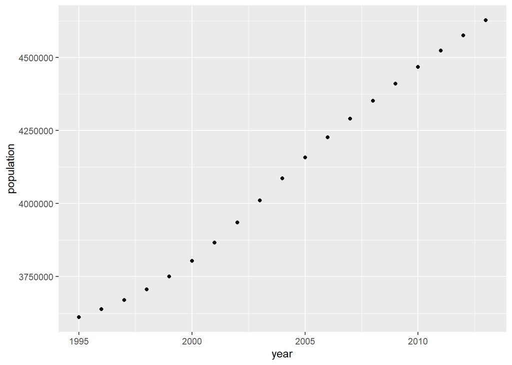

```r
dataset_for_plot <- population %>%
  filter(country == "Ireland")

ggplot(data = dataset_for_plot) +
  geom_point(mapping = aes(x = year, y = population))
```

Nice. We can easily make a line plot by swapping `geom_point` for `geom_line` in the above.

Let’s make a line plot with the countries France, Germany and Spain each having a different line colour, plotting their populations over time.

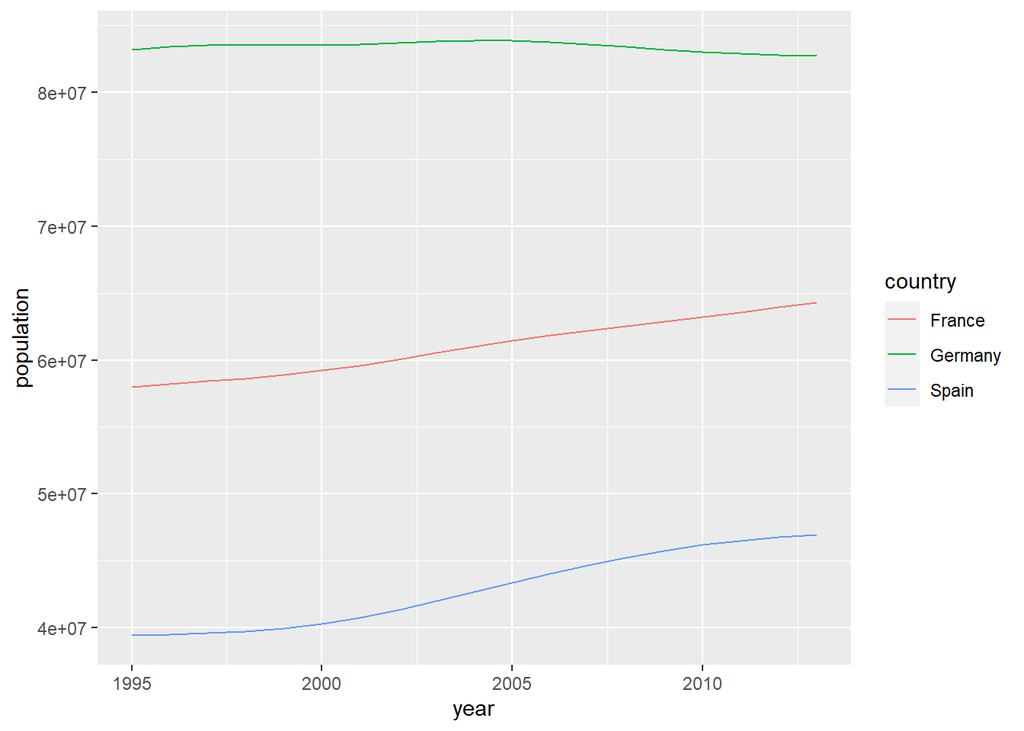

```r
dataset_for_plot <- population %>%
  filter(country %in% c("France", "Germany", "Spain"))

ggplot(data = dataset_for_plot) +
  geom_line(mapping = aes(x = year, y = population, colour = country))
```

Great. Let’s make a column plot using `geom_col`. We’ll filter a couple of countries and take the data just from 2010.

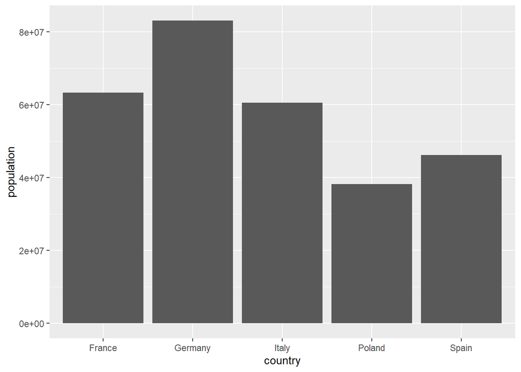

```r
dataset_for_plot <- population %>%
  filter(country %in% c("France", "Germany", "Spain", "Italy", "Poland"), year == 2010)

ggplot(data = dataset_for_plot) +
  geom_col(mapping = aes(x = country, y = population))
```

We can turn this into a bar plot easily by adding `coord_flip()`:

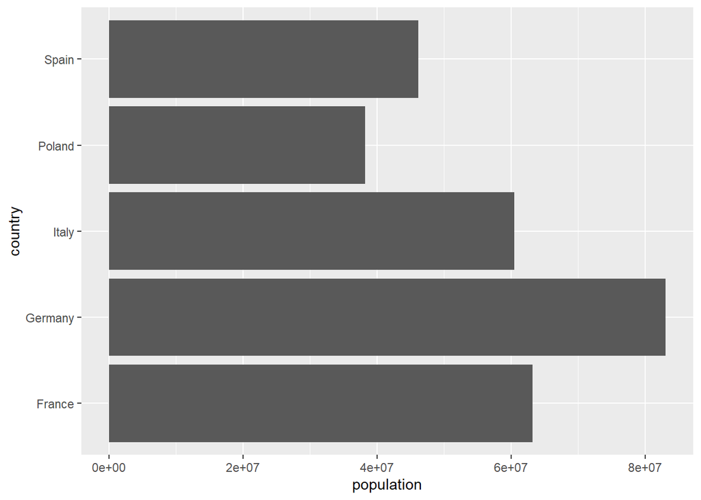

```r
ggplot(data = dataset_for_plot) +
  geom_col(mapping = aes(x = country, y = population)) +
  coord_flip()
```

Let’s return to our line plot for France, Germany and Spain. If we wanted lines and points it would make more sense to put the `aes` mapping function within the `ggplot` rather than in both the `geom_line` and `geom_point`:

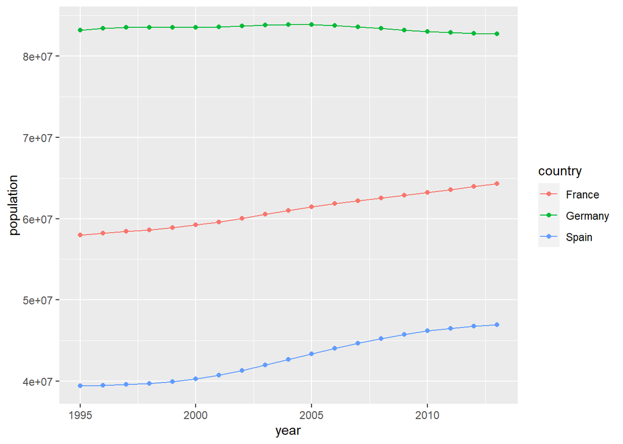

```r
dataset_for_plot <- population %>%
  filter(country %in% c("France", "Germany", "Spain"))

ggplot(data = dataset_for_plot , mapping = aes(x = year, y = population, colour = country)) +
  geom_line() +
  geom_point()
```

### Adjusting labels

Let’s do the same plot, but change some of the labels. We’ll change the y-axis label to “Persons”, leave both the x-axis title and legend title blank, and set the heading to “Population of selected countries over time”. All of that can be done through the `labs` function.

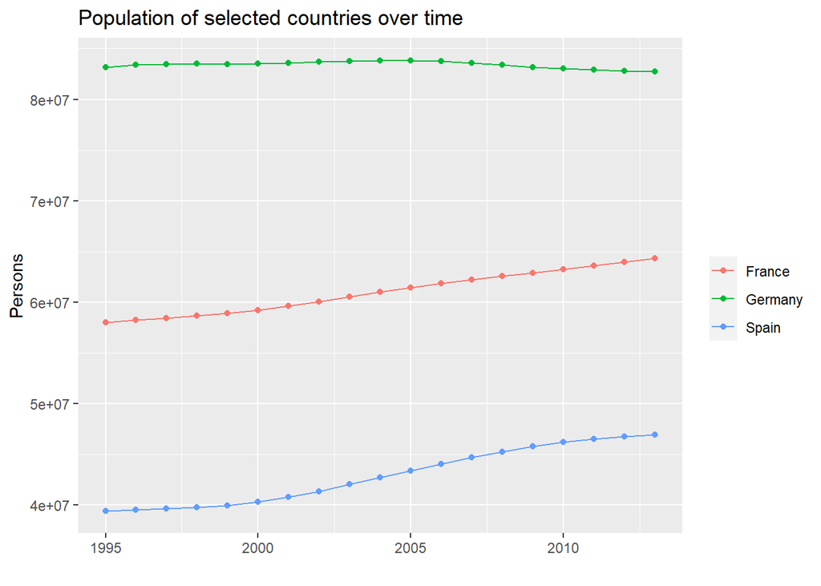

```r
ggplot(data = dataset_for_plot , mapping = aes(x = year, y = population, colour = country)) +
  geom_line() +
  geom_point() +
  labs(x = "",
       y = "Persons",
       colour = "",
       title = "Population of selected countries over time")
```

### Adjusting axes

Let’s do the same plot (we’ll forget about the labels) but make two adjustments to the y-axis. We will use the function `scale_y_continuous` which has lots of tools within it for tailoring a continuous y-axis.

The function `scale_y_continuous` is one of a large family of functions with the format `scale_DIM_FORMAT` where DIM is the dimension (x, y, fill, colour, etc.) and FORMAT is the type of axis. See the second page of the ggplot2 cheatsheet for more information.

We’ll change the limits of the y-axis so that it starts at zero. This is done using the `limits` argument to `scale_y_continuous`, and `limits` takes a vector of length two, the first entry being the lower limit and the second entry being the upper limit. I’ll set the lower limit to zero, but I’ll leave the upper limit as `NA`, meaning that I’ll leave it up to the data to determine how high the y-axis should go.

I’ll change the labels on the y so that they show the whole number with comma separators rather than the scientific format which has appeared. That is done with the `labels` argument to `scale_y_continuous`. I’m setting that argument as being equal to `comma`, which is actually a function from the package scales. This package provide a bunch of tools that make it easier to tailor axes and legends. The scales package is installed with tidyverse but needs to be loaded in using `library(scales)`. If the y-axis needed to be formatted as a percentage, then you’d replace `comma` with `percent` (`percent` is another function from scales).

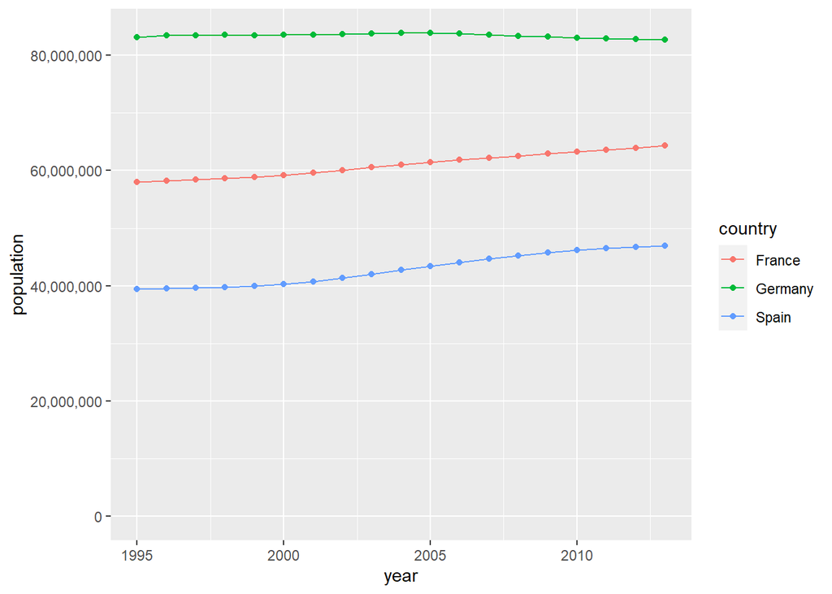

```r
library(scales)

ggplot(data = dataset_for_plot , mapping = aes(x = year, y = population, colour = country)) +
  geom_line() +
  geom_point() +
  scale_y_continuous(limits = c(0,NA) , label = comma )
```

There are tons of other ways to edit the appearance of plots through ggplot, but these would be beyond a crash course. I’ll wrap up with one tool for altering the appearance which is to add a theme. There are 8 themes including the default `theme_grey()`. There is `theme_light()`, `theme_dark()`, `theme_bw()`. My favourite is `theme_minimal()`. Use the help (`?theme_grey`) to find out more.

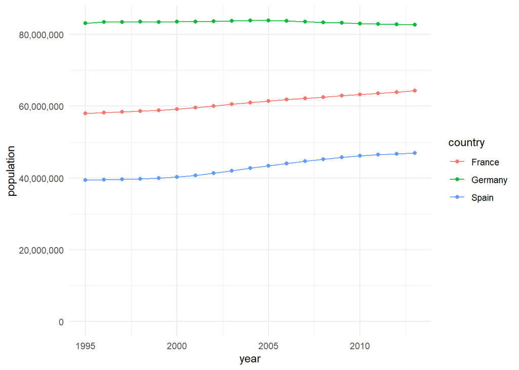

```r
library(scales)

ggplot(data = dataset_for_plot , mapping = aes(x = year, y = population, colour = country)) +
  geom_line() +
  geom_point() +
  scale_y_continuous(limits = c(0,NA) , label = comma ) +
  theme_minimal()
```